# Introduction to sparklyr

We will largely follow Chapters 2 and 3 of Mastering Spark with R, https://therinspark.com/.

## Installation

If you are using your own computer rather than Noteable, you may need to install Java 8 before you install Spark. Do it here: https://www.java.com/en/download/.

The first time you run this code, you should install Spark by typing the following command into the console:

```r
spark_install('3.3')
```

This only needs to be done once on the first run.

Next, we will install sparklyr and load up required packages.

```r
if (!require('sparklyr')){
  install.packages('sparklyr')
}

library(sparklyr)
library(dplyr)
library(ggplot2)
```

## Connecting

You will be using the machine you are working on as a local cluster. This is just so you can familiarise yourself with using sparklyr. In practice, we would connect to an external cluster.

mtcars is a dataset that is built into R that we will use as an example.

```r
sc = spark_connect(master = "local")
cars = copy_to(sc, mtcars, overwrite = TRUE)
```

## Data input/output

### Write to a csv file:

This will create a folder in your working directory called cars.csv. It contains a csv with the cars data in it.

```r
spark_write_csv(cars, 'cars.csv')
```

Note that running this more than once will result in an error because spark_write_csv will not overwrite a folder you have already created. You may need to delete the folder cars.csv in your working directory in order to re-run.

### Read from a csv file:

```r
spark_read_csv(sc, 'cars.csv')
```

```
## # Source: spark<cars_2897114c_0a16_4eb8_a5d6_fd2a83c07e1a> [?? x 11]
##      mpg   cyl  disp    hp  drat    wt  qsec    vs    am  gear  carb
##    <dbl> <dbl> <dbl> <dbl> <dbl> <dbl> <dbl> <dbl> <dbl> <dbl> <dbl>
##  1  21       6  160    110  3.9   2.62  16.5     0     1     4     4
##  2  21       6  160    110  3.9   2.88  17.0     0     1     4     4
##  3  22.8     4  108     93  3.85  2.32  18.6     1     1     4     1
##  4  21.4     6  258    110  3.08  3.22  19.4     1     0     3     1
##  5  18.7     8  360    175  3.15  3.44  17.0     0     0     3     2
##  6  18.1     6  225    105  2.76  3.46  20.2     1     0     3     1
##  7  14.3     8  360    245  3.21  3.57  15.8     0     0     3     4
##  8  24.4     4  147.    62  3.69  3.19  20       1     0     4     2
##  9  22.8     4  141.    95  3.92  3.15  22.9     1     0     4     2
## 10  19.2     6  168.   123  3.92  3.44  18.3     1     0     4     4
## # ... with more rows
```

## Data wrangling

Familiar commands from dplyr work as you would expect, but now they instead connect to Spark and are run in parallel across the cluster.

### Create a new column.

```r
cars = mutate(cars, transmission = ifelse(am == 0, "automatic", "manual"))
```

### Select columns.

```r
select(cars, am, transmission)
```

```
## # Source: spark<?> [?? x 2]
##       am transmission
##    <dbl> <chr>
##  1     1 manual
##  2     1 manual
##  3     1 manual
##  4     0 automatic
##  5     0 automatic
##  6     0 automatic
##  7     0 automatic
##  8     0 automatic
##  9     0 automatic
## 10     0 automatic
## # ... with more rows
```

### Calculate the mean of each column.

```r
summarise_all(cars, mean, na.rm = TRUE)
```

```
## # Source: spark<?> [?? x 12]
##     mpg   cyl  disp    hp  drat    wt  qsec    vs    am  gear  carb transmission
##   <dbl> <dbl> <dbl> <dbl> <dbl> <dbl> <dbl> <dbl> <dbl> <dbl> <dbl>        <dbl>
## 1  20.1  6.19  231.  147.  3.60  3.22  17.8 0.438 0.406  3.69  2.81           NA
```

## Plots

Creating a plot isn’t usually highly computationally demanding. Therefore, sparklyr does not have a full-fledged equivalent of ggplot. It is typically best to perform all data manipulations in Spark, then bring the result back to R using the collect() command. Finally, we use the regular ggplot package to make the graph.

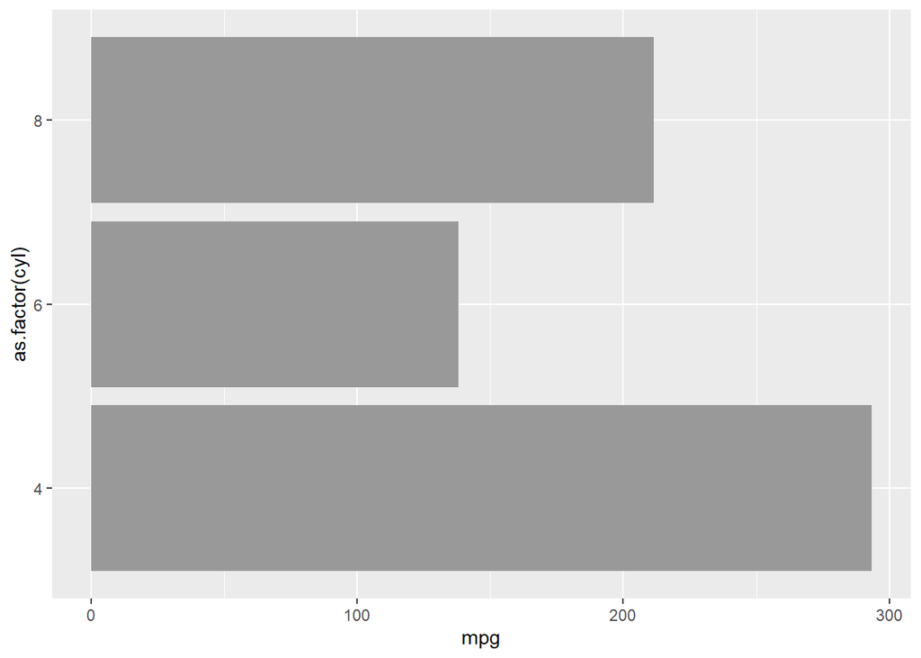

```r
car_group = cars %>%
    group_by(cyl) %>%
    summarise(mpg = sum(mpg, na.rm = TRUE)) %>%
    collect()

ggplot(aes(as.factor(cyl), mpg), data = car_group) +
  geom_col(fill = "#999999") +
  coord_flip()
```

## Models, in brief

We will go into more details about these models in coming lectures.

### OLS

```r
ols_model = ml_linear_regression(cars, mpg ~ hp + disp)
summary(ols_model)
```

```
## Deviance Residuals:
##     Min      1Q  Median      3Q     Max
## -4.7945 -2.3036 -0.8246  1.8582  6.9363
##
## Coefficients:
## (Intercept)          hp        disp
## 30.73590425 -0.02484008 -0.03034628
##
## R-Squared: 0.7482
## Root Mean Squared Error: 2.976
```

### Logistic regression

```r
lr_model = ml_logistic_regression(cars, am ~ hp + disp)
summary(lr_model)
```

```
## Coefficients:
## (Intercept)          hp        disp
##  1.40342344  0.12170174 -0.09517974
```

### Multilayer perceptron

```r
mlp_model = ml_multilayer_perceptron_classifier(
    cars,
    am ~ hp + disp,
    layers = c(2, 8, 8, 2))
predictions = ml_predict(mlp_model, cars)

select(predictions, prediction, probability_0, probability_1)
```

```
## # Source: spark<?> [?? x 3]
##    prediction probability_0 probability_1
##         <dbl>         <dbl>         <dbl>
##  1          0      6.44e- 1      3.56e- 1
##  2          0      6.44e- 1      3.56e- 1
##  3          1      1.94e-16      1   e+ 0
##  4          0      1   e+ 0      4.13e-28
##  5          0      1   e+ 0      4.13e-28
##  6          0      1   e+ 0      4.13e-28
##  7          0      6.44e- 1      3.56e- 1
##  8          0      1   e+ 0      4.13e-28
##  9          0      6.44e- 1      3.56e- 1
## 10          0      6.44e- 1      3.56e- 1
## # ... with more rows
```

### Other models

Apache Spark supports many other models - I have just chosen a few to look at more closely. I encourage you to explore others! See documentation here: https://spark.apache.org/docs/latest/ml-classification-regression.html

## Disconnecting

```r
spark_disconnect(sc)
```